# CapStoneNewMrkDown

Rekha Vellanki

Oct, 2018

#### Relation of variables on fuel consumption

The plot shows that as the number of cylinders increases, the city fuel efficiency decreases. In other words, lower the cylinders, the better is the fuel consumption. So it looks like there is a negative correlation on fuel efficiency with increase in number of cylinders. To understand the extent of significance , statistical analysis is run on these 2 variables and plots are shown in the later part.

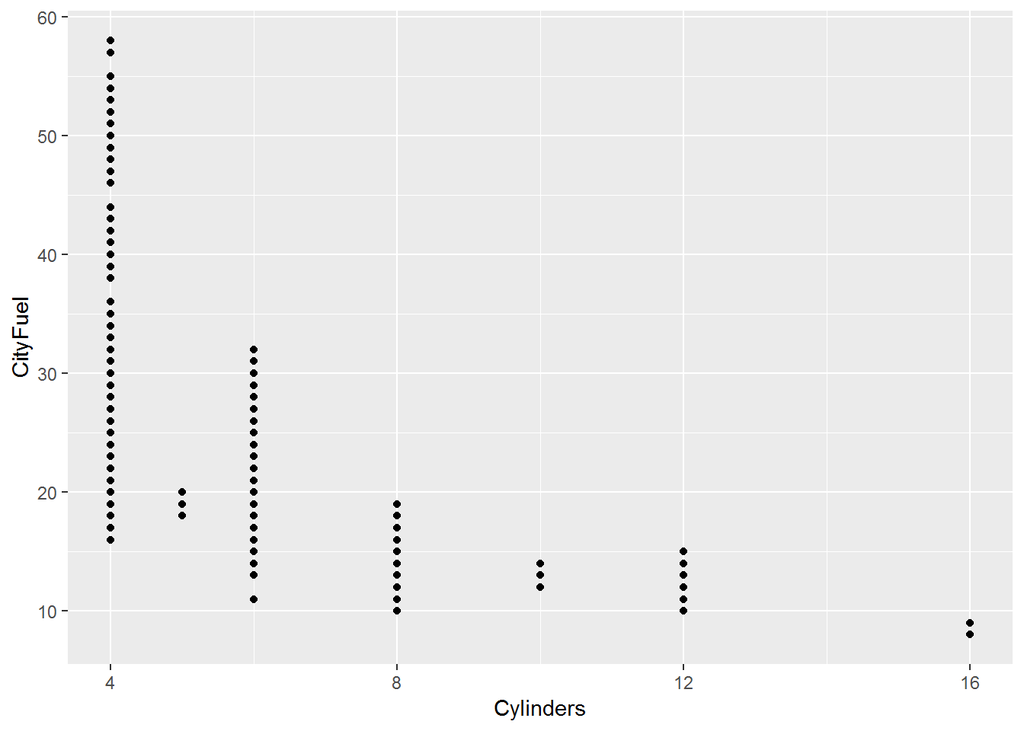

#### impact of transmission type on cityfuel

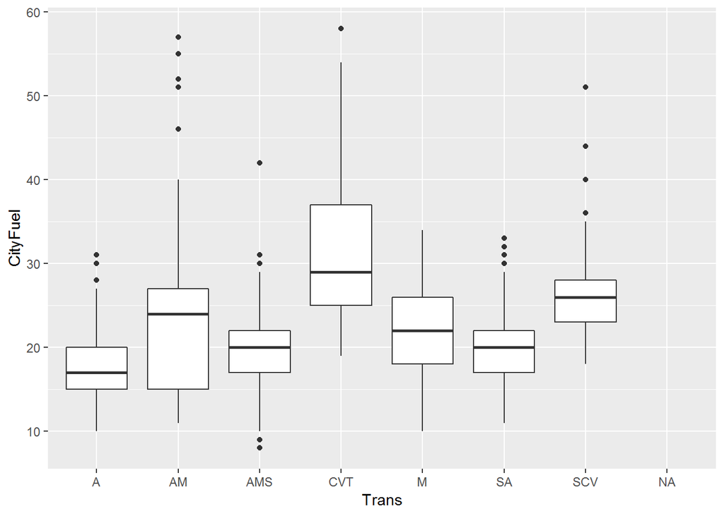

#### linear regression of cylinders and Cityfuel.

A scatterplot gives a comparison between 2 variables. Below is a scatter plot showing the visual comparison of City fuel (mpg) and cylinders. The below scatter plot also use a regression line to see the decline of fuel efficiency (mpg) from the 4 cylinder vehicles to the 8-12 cylinder vehicles. The line shows how mpg decreases with increasing number of cylinders. The car lines that have high fuel efficiency are compact, subcompact and small suv’s with 4 cylinders.

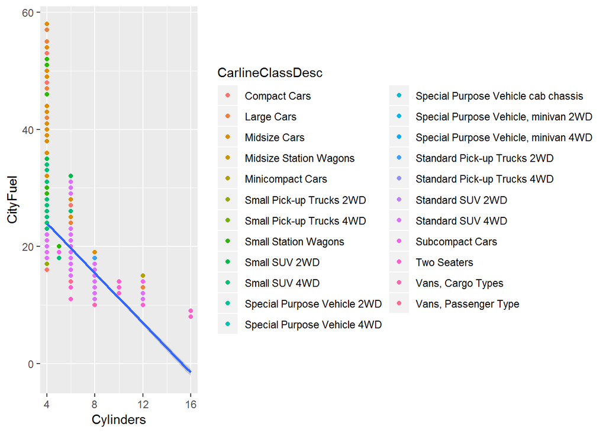

Finding correlations between different variables.

Key observations are cylinders having moderate -ve correlation with fuel consumption , i.e higher the number of cylinders, lower the fuel efficiency. So, cars with lower number of cylinders give more mile per gallon.

Cylinders and engine displacement show positive correlation. So, Engine displacement correlation to city fuel is similar to Cylinders. Higher the engine displacement, lower is the fuel efficiency.

CityFuel and gears show moderate negative correlation. Higher the number of gears, lower the fuel efficiency.

city fuel and annual fuel cost show moderate to good -ve correlation. The fuel cost spent on cars with higher mile per gallon is lower than fuel cost spent on cars with lower miles per gallon.

City fuel and GHG rating show moderate positive correlation. Higher the mile per gallon, higher the GHG rating (lower the emissions). Higher GHG rating is better for the environment.

From the observations and correlations, machine learing problem on this dataset is a supervised problem. The fuel usage will be predicted based on the features identified. The features are all part of the manfacturer configuration - cylinders, engine displacment and transmission. Also added gears that showed moderate correlation with city fuel. The machine learing techique used is linear regression. The success will be evaluated based on the linear regression results. If the results show the correlation is not by chance and show significant difference. Also, all the linear regression assumptions of linearity, normality , homoscedasticity should be met.

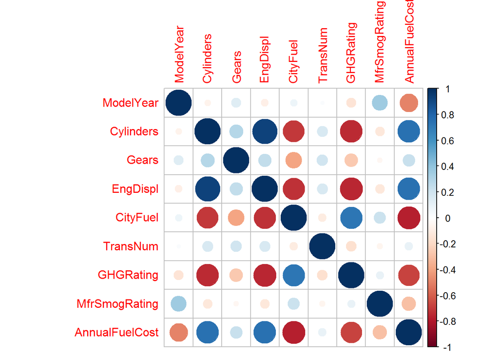

###### Linear model of all variables on mpg

The model is to predict the impact of multiple variables on city fuel (mpg). The features included in the model are engine displacment, gears, and transmission type.

Before running the model, checked to see if the cityfuel distribution is normal. As it is skewed positively to right, ran log ransformation on cityfuel. the distribution curve of city fuel after log transformation shows normal curve.

Scaled all the numerical variables of the data set. Ran the single linear regression first.

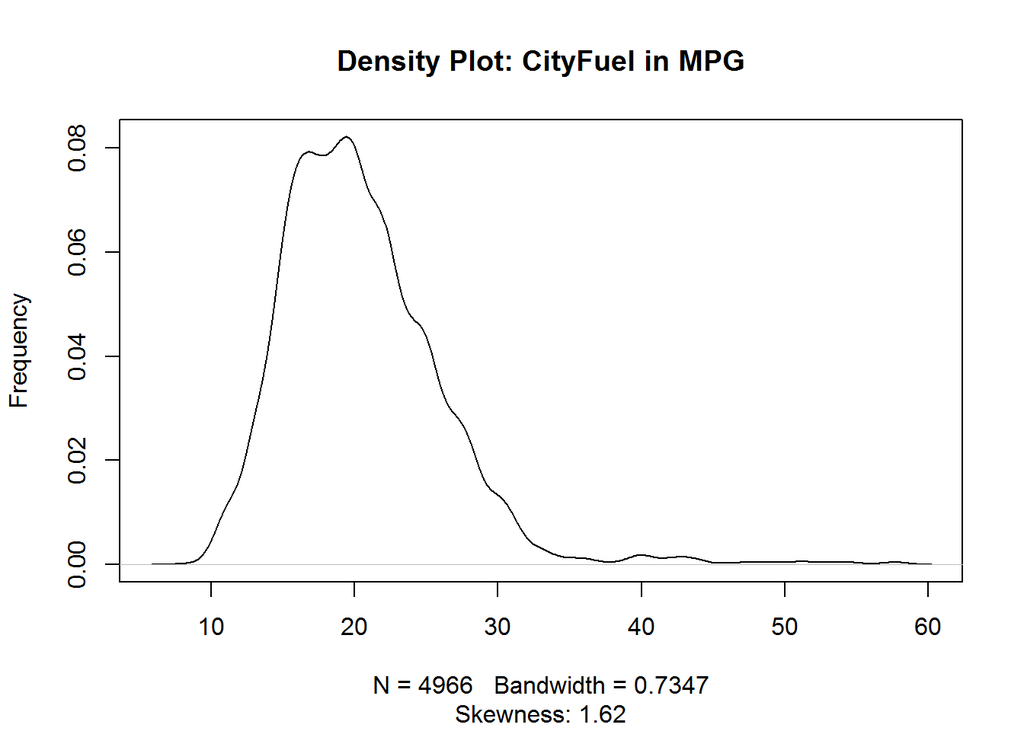

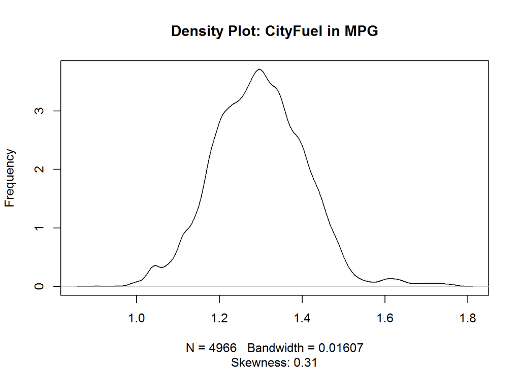

#### Correlation between City Fuel and Engine Displacment

The engine displacement (eng size, , eng volume in liters) is one of the features in manufacturer configurations. It is highly negatively correlated with City Fuel - the higher the eng size, the lower is the fuel efficiency

```
## [1] -0.8364356
```

# Results of Single Linear Regression (Engine Displacment on City Fuel)

Having seen the correlation between engine size and city fuel, ran a linear regression model to look at how the significance is. The significant codes(asterisks) indicate that the feature Engine Displacemnent is very likely to have an impact on the dependent variable. But we need to see how significant it is. As the output shows, the chosen feature engine displacement explains 70% observed variance on the dependent variable city fuel.

```
##
## Call:
## lm(formula = CityFuel ~ EngDispl, data = mydatafcT)
##
## Residuals:
##      Min       1Q   Median       3Q      Max
## -0.21212 -0.03511 -0.00580  0.02766  0.37949
##
## Coefficients:
##              Estimate Std. Error t value Pr(>|t|)
## (Intercept)  1.531157   0.002346   652.7   <2e-16 ***
## EngDispl    -0.510320   0.004746  -107.5   <2e-16 ***
## ---
## Signif. codes:  0 '***' 0.001 '**' 0.01 '*' 0.05 '.' 0.1 ' ' 1
##
## Residual standard error: 0.06074 on 4964 degrees of freedom
## Multiple R-squared:  0.6996, Adjusted R-squared:  0.6996
## F-statistic: 1.156e+04 on 1 and 4964 DF,  p-value: < 2.2e-16
```

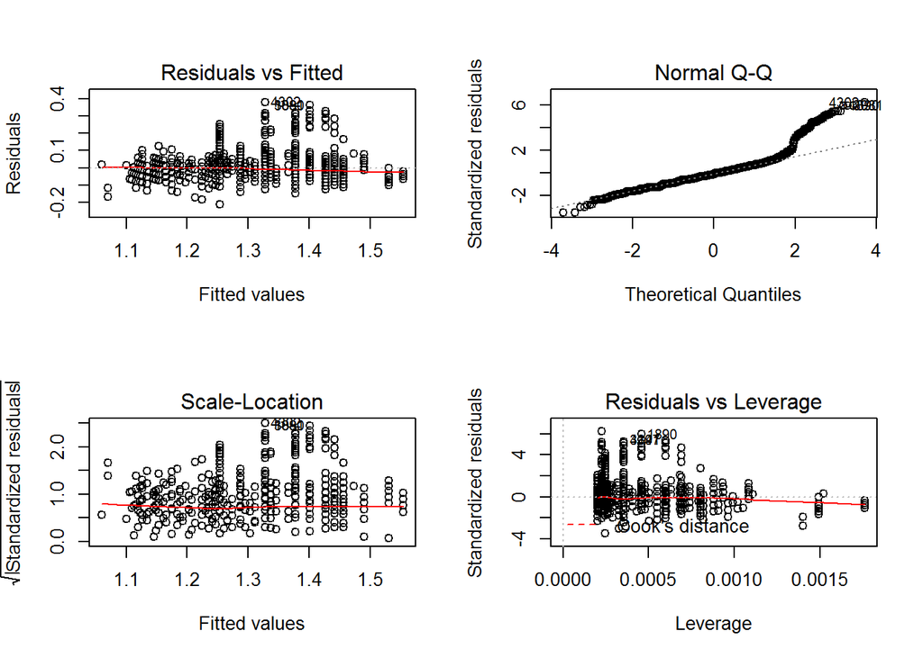

```
##
## Call:
## lm(formula = CityFuel ~ EngDispl, data = mydatafcT)
##
## Coefficients:
## (Intercept)     EngDispl
##      1.5312      -0.5103
##
##
## ASSESSMENT OF THE LINEAR MODEL ASSUMPTIONS
## USING THE GLOBAL TEST ON 4 DEGREES-OF-FREEDOM:
## Level of Significance =  0.05
##
## Call:
##  gvlma(x = fuelmodel)
##
##                        Value   p-value                   Decision
## Global Stat        9663.4328 0.000e+00 Assumptions NOT satisfied!
## Skewness           2080.4876 0.000e+00 Assumptions NOT satisfied!
## Kurtosis           7561.5030 0.000e+00 Assumptions NOT satisfied!
## Link Function        20.6889 5.403e-06 Assumptions NOT satisfied!
## Heteroscedasticity    0.7532 3.855e-01    Assumptions acceptable.
```

# Results of Multiple Regression model(Engine Displacment and Transmission on City Fuel)

One of the features of manufacturer configuration is transmission type. Created a two level categorical variable for tranmission type and ran the model with engine displacement and transmission to see the impact on City fuel. As the output shows, both features show they have very likely to have impact on City Fuel. And, compared to the single linear model with just engine size, this model is same as the other give that residuals remained almost same..

Assumptions for this model as well show slight non linearity and normality is not met.

```
##
## Call:
## lm(formula = CityFuel ~ EngDispl + TransNum, data = mydatafcT)
##
## Residuals:
##      Min       1Q   Median       3Q      Max
## -0.21377 -0.03825 -0.00046  0.02991  0.37695
##
## Coefficients:
##              Estimate Std. Error  t value Pr(>|t|)
## (Intercept)  1.522280   0.002808  542.187  < 2e-16 ***
## EngDispl    -0.516401   0.004849 -106.492  < 2e-16 ***
## TransNum     0.013841   0.002423    5.712 1.18e-08 ***
## ---
## Signif. codes:  0 '***' 0.001 '**' 0.01 '*' 0.05 '.' 0.1 ' ' 1
##
## Residual standard error: 0.06055 on 4963 degrees of freedom
## Multiple R-squared:  0.7016, Adjusted R-squared:  0.7015
## F-statistic:  5834 on 2 and 4963 DF,  p-value: < 2.2e-16
```

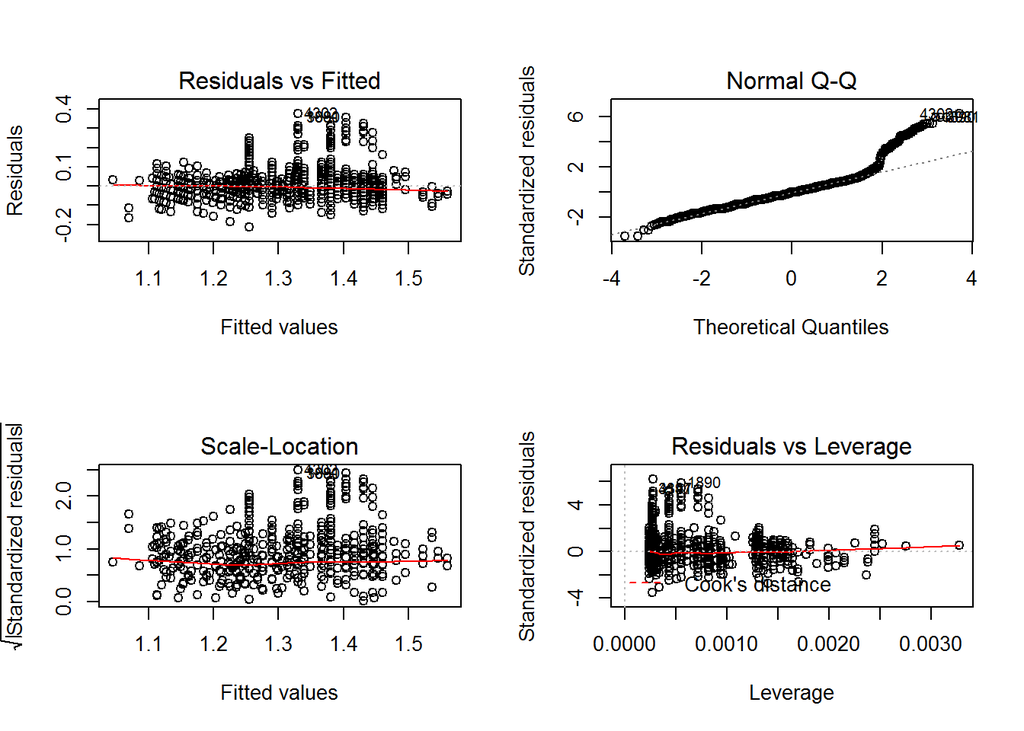

```
##
## Call:
## lm(formula = CityFuel ~ EngDispl + TransNum, data = mydatafcT)
##
## Coefficients:
## (Intercept)     EngDispl     TransNum
##     1.52228     -0.51640      0.01384
##
##
## ASSESSMENT OF THE LINEAR MODEL ASSUMPTIONS
## USING THE GLOBAL TEST ON 4 DEGREES-OF-FREEDOM:
## Level of Significance =  0.05
##
## Call:
##  gvlma(x = fuelmodel1)
##
##                        Value   p-value                   Decision
## Global Stat        8972.0151 0.0000000 Assumptions NOT satisfied!
## Skewness           1941.8550 0.0000000 Assumptions NOT satisfied!
## Kurtosis           7015.8513 0.0000000 Assumptions NOT satisfied!
## Link Function        13.6558 0.0002196 Assumptions NOT satisfied!
## Heteroscedasticity    0.6531 0.4190233    Assumptions acceptable.
```

##### Results of Multiple Regression model(Engine Displacment and Transmission and Gears on City Fuel )

In this model, included Gears as feature to see the impact on City Fuel. This model shows the highest residual and adjusted resdiuals , 0.72, showing it is the best model out of the 3 to predict City fuel.

From an assumptions standpoint, this model has homoscedastic residuals (homoscedasticity met) and also shows the features are truly continuous. (link function assumption met) Although , we still see some non linearity and skewness, not meeting the assumption of normality.

```
##
## Call:
## lm(formula = CityFuel ~ EngDispl + TransNum + Gears, data = mydatafcT)
##
## Residuals:
##      Min       1Q   Median       3Q      Max
## -0.21290 -0.03493 -0.00306  0.03005  0.37160
##
## Coefficients:
##               Estimate Std. Error t value Pr(>|t|)
## (Intercept)  1.5692155  0.0040519  387.28  < 2e-16 ***
## EngDispl    -0.4961333  0.0049055 -101.14  < 2e-16 ***
## TransNum     0.0192639  0.0023900    8.06 9.46e-16 ***
## Gears       -0.0091790  0.0005837  -15.73  < 2e-16 ***
## ---
## Signif. codes:  0 '***' 0.001 '**' 0.01 '*' 0.05 '.' 0.1 ' ' 1
##
## Residual standard error: 0.0591 on 4962 degrees of freedom
## Multiple R-squared:  0.7158, Adjusted R-squared:  0.7156
## F-statistic:  4165 on 3 and 4962 DF,  p-value: < 2.2e-16
```

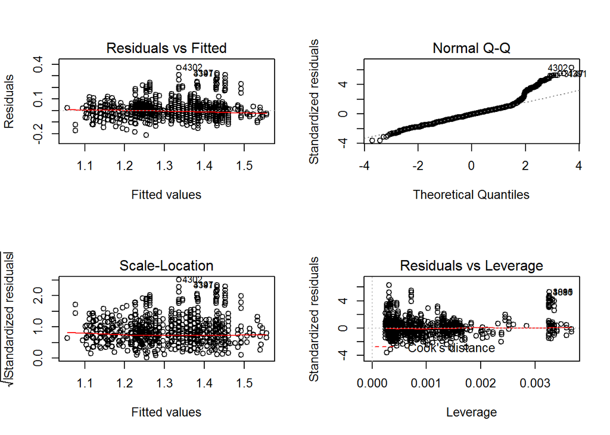

```
##
## Call:
## lm(formula = CityFuel ~ EngDispl + TransNum + Gears, data = mydatafcT)
##
## Coefficients:
## (Intercept)     EngDispl     TransNum        Gears
##    1.569215    -0.496133     0.019264    -0.009179
##
##
## ASSESSMENT OF THE LINEAR MODEL ASSUMPTIONS
## USING THE GLOBAL TEST ON 4 DEGREES-OF-FREEDOM:
## Level of Significance =  0.05
##
## Call:
##  gvlma(x = fuelmodel2)
##
##                        Value p-value                   Decision
## Global Stat        5283.5444  0.0000 Assumptions NOT satisfied!
## Skewness           1239.8381  0.0000 Assumptions NOT satisfied!
## Kurtosis           4041.6742  0.0000 Assumptions NOT satisfied!
## Link Function         1.4180  0.2337    Assumptions acceptable.
## Heteroscedasticity    0.6142  0.4332    Assumptions acceptable.
```

#### Summary of Machine learning Analysis

Linear regression model was chosen to show the impact of selected features on City Fuel. The manufacture configuration includes Cylinders, Engine displacement, transmission type. So selected these as the features for the dependent variable City Fuel. Cylinders was excluded in the model, as it shows multi collinearity with Engine displacement. Engine Displacement shows high negative correlation (-0.83) with City Fuel. Gears is another feature in multiple regression as it shows moderate correlation with city fuel.

- All 3 features run together in the model showed siginificant and better impact (72%) on city fuel, compared to each of them individually. The model would have been a good fit if all the assumtions of linear model are met. But the model shows some non linearity and skewness in normality. Although the model shows significance, we cannot use the model to predict fuel usage as it did not meet all assumptions of linear model. Non parametric regression can be used on existing data set as it does not look for linearity.